# Estatística Estatística Espacial

## Aplicação II: Construindo mapa temático

#### Bibliotecas que serão utilizadas:

```r
library(ggplot2)
library(dplyr)
library(viridis)
library(geobr)
library(sf)
library(maptools)
library(leaflet)
library(ggspatial)
```

```r
brasil.ufs <- st_read("malhas/brasil_ufs_2019.shp")
```

#### Primeiro, vamos fazer um gráfico apenas com as geometrias.

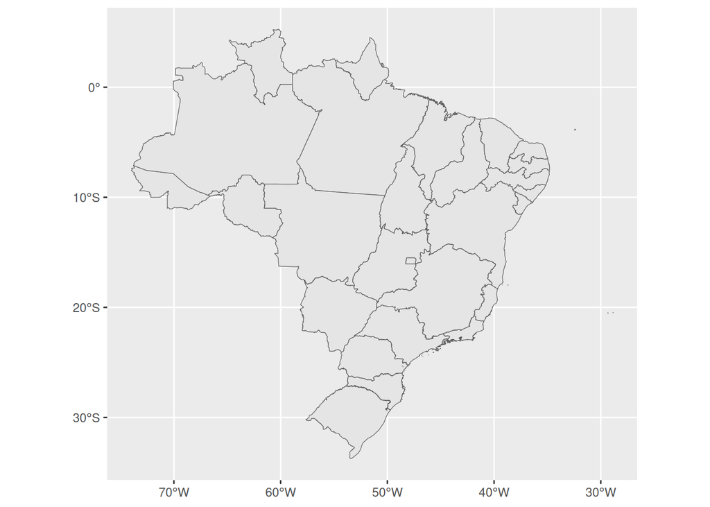

```r
ggplot(brasil.ufs) + geom_sf()
```

- Para a construção de um mapa onde cada estado recebe uma cor de acordo com a sua região geogrática, procedemos da seguinte forma:

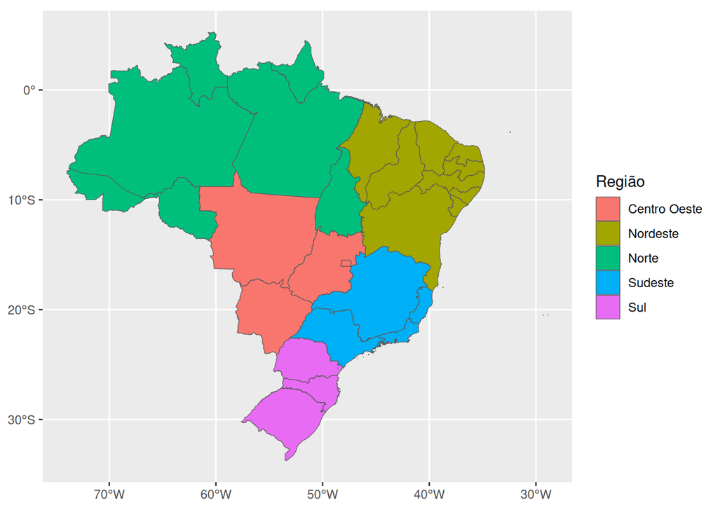

```r
ggplot(brasil.ufs) + geom_sf(aes(fill = nam_rgn)) + labs(fill = "Região")
```

- Agora utilizaremos dados relativos a porcentagem de municípios com rede de esgoto de acordo com a unidade da federação ([fonte dos dados](https://pt.wikipedia.org/wiki/Lista_de_unidades_federativas_do_Brasil_por_acesso_%C3%A0_rede_de_esgoto) ) para fazer um gráfico. Vamos associar esses dados a tabela de acordo com a variável State e padronizaremos a porcentagem para variar de 0 a 100.

```r
# Entrando com os dados observados na wikipedia
acesso_san <- data.frame(cod_stt = c(12, 27, 16, 13, 29, 23, 53, 32, 52, 21, 51,
    50, 31, 15, 25, 41, 26, 22, 33, 24, 43, 11, 14, 42, 35, 28, 17), com_rede = c(0.273,
    0.412, 0.313, 0.177, 0.513, 0.696, 1, 0.974, 0.28, 0.065, 0.191, 0.449, 0.916,
    0.063, 0.731, 0.421, 0.881, 0.045, 0.924, 0.353, 0.405, 0.096, 0.4, 0.352, 0.998,
    0.347, 0.129))
```

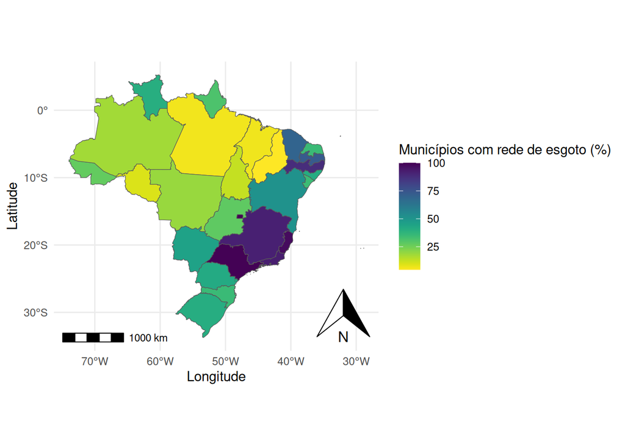

```r
# Construindo o mapa com ggplot
brasil.ufs |>
    left_join(acesso_san, by = "cod_stt") |>
    mutate(com_rede = 100 * com_rede) |>
    ggplot(aes(fill = com_rede), color = "black") + geom_sf() + scale_fill_viridis(name = "Municípios com rede de esgoto (%)",
    direction = -1) + xlab("Longitude") + ylab("Latitude") + annotation_scale(location = "bl") +
    annotation_north_arrow(location = "br") + theme_minimal()
```

- Uma forma alteranativa de apresentar esses mesmos dados se dá pela apresentação de círculos com raios proporcionais a porcentgem de municípios com rede de esgoto no centroide de cada geometria (nesse caso, UF).

```r
# Juntando o banco com os dados + malha
coord_pontos <- brasil.ufs |>
    left_join(acesso_san, by = "cod_stt") |>
    mutate(com_rede = 100 * com_rede) |>
    st_centroid()
```

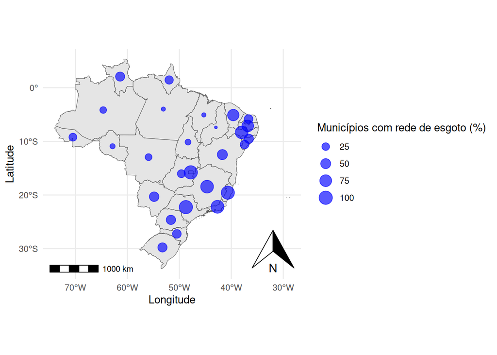

```r
# Construindo o mapa com ggplot
ggplot(brasil.ufs) + geom_sf() + geom_sf(data = coord_pontos, aes(size = com_rede),
    col = "blue", alpha = 0.65, show.legend = "point") + scale_size_continuous(name = "Municípios com rede de esgoto (%)") +
    xlab("Longitude") + ylab("Latitude") + annotation_scale(location = "bl") + annotation_north_arrow(location = "br") +
    theme_minimal()
```

- Uma alternativa interativa para trabalhar com mapas é com a utilização do pacote *leaflet*

```r
data.frame(st_coordinates(coord_pontos), com_rede = coord_pontos$com_rede, UF = coord_pontos$nam_stt) |>
    leaflet() |>
    addTiles() |>
    addCircleMarkers(~X, ~Y, label = ~as.character(paste0(UF, ": ", com_rede, "%")),
        labelOptions = labelOptions(textsize = "13px"), radius = ~com_rede/10, fillOpacity = 0.5)
```

[interactive chart not shown]

[Créditos ao Thiago Mendonça](https://www.tiagoms.com/post/mapa/)

## Bibliografia sugerida

- Druck, S.; Carvalho, M.S.; Câmara, G.; Monteiro, A.V.M. (eds). [Análise Espacial de Dados Geográficos](http://www.dpi.inpe.br/gilberto/livro/analise/). Brasília, EMBRAPA, 2004.
- Interactive Spatial Data Analysis by Trevor C. Bailey , Anthony C. Gatrell Routledge, 1995
- Applied Spatial Statistics for Public Health Data; Lance A. Waller, Carol A. Gotway Wiley-Interscience 1St ed. 2004
- Applied Spatial Data Analysis with R; Roger S. Bivand, Edzer Pebesma , Virgilio Gomez-Rubio Springer; Edição: 2nd ed. 2013
- Geocomputation with R by Robin Lovelace, Jakub Nowosad and Jannes Muenchow. [Geocomputation with R](https://geocompr.robinlovelace.net/), 2021.
- Spatial Statistics Workbook of Department of Criminology at the University of Manchester by Reka Solymosi and Juanjo Medina [Crime Mapping in R](https://maczokni.github.io/crime_mapping_textbook/)
- Spatial Data Science with R [Spatial Data Science with R](https://rspatial.org/raster/index.html)
- GeoComputation and Spatial Analysis practicals by Lex Comber [On-line Book](https://bookdown.org/lexcomber/GEOG3195/)
- GEOG5917 Big Data & Consumer Analytics - RStudio Practicals by Lex Comber [On-line Book](https://bookdown.org/lexcomber/GEOG5917/)